# Bioinformatics Class 8

Barry Grant

4/26/2018

# K-means ckustering

Lets make up some data to try K-means on:

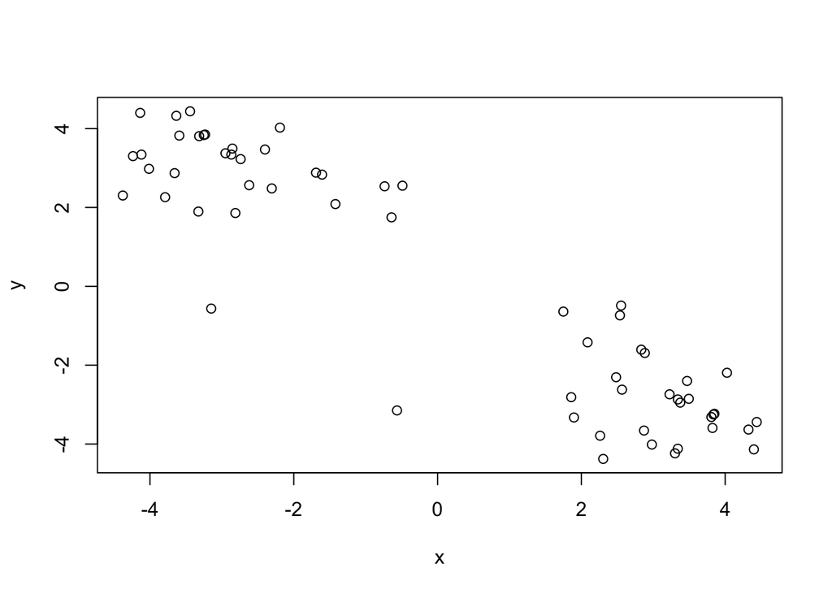

```r
# Generate some example data for clustering
tmp <- c(rnorm(30,-3), rnorm(30,3))
x <- cbind(x=tmp, y=rev(tmp))

plot(x)
```

Our tasks - Use the kmeans() function setting k to 2 and nstart=20

```r
km <- kmeans(x, centers = 2, nstart=20)
km
```

```
## K-means clustering with 2 clusters of sizes 30, 30
##
## Cluster means:
##           x         y
## 1 -2.853321  2.978320
## 2  2.978320 -2.853321
##
## Clustering vector:
##  [1] 1 1 1 1 1 1 1 1 1 1 1 1 1 1 1 1 1 1 1 1 1 1 1 1 1 1 1 1 1 1 2 2 2 2 2
## [36] 2 2 2 2 2 2 2 2 2 2 2 2 2 2 2 2 2 2 2 2 2 2 2 2 2
##
## Within cluster sum of squares by cluster:
## [1] 63.76634 63.76634
##  (between_SS / total_SS =  88.9 %)
##
## Available components:
##
## [1] "cluster"      "centers"      "totss"        "withinss"
## [5] "tot.withinss" "betweenss"    "size"         "iter"
## [9] "ifault"
```

```r
km$cluster
```

```
##  [1] 1 1 1 1 1 1 1 1 1 1 1 1 1 1 1 1 1 1 1 1 1 1 1 1 1 1 1 1 1 1 2 2 2 2 2
## [36] 2 2 2 2 2 2 2 2 2 2 2 2 2 2 2 2 2 2 2 2 2 2 2 2 2
```

Inspect/print the results

Q. How many points are in each cluster?

```r
km$size
```

```
## [1] 30 30
```

Q. What ‘component’ of your result object details - cluster size? - cluster assignment/membership? - cluster center?

```r
# cluster assignment/membership?
km$cluster
```

```
##  [1] 1 1 1 1 1 1 1 1 1 1 1 1 1 1 1 1 1 1 1 1 1 1 1 1 1 1 1 1 1 1 2 2 2 2 2
## [36] 2 2 2 2 2 2 2 2 2 2 2 2 2 2 2 2 2 2 2 2 2 2 2 2 2
```

```r
# cluster center
km$centers
```

```
##           x         y
## 1 -2.853321  2.978320
## 2  2.978320 -2.853321
```

Plot x colored by the kmeans cluster assignment and add cluster centers as blue points

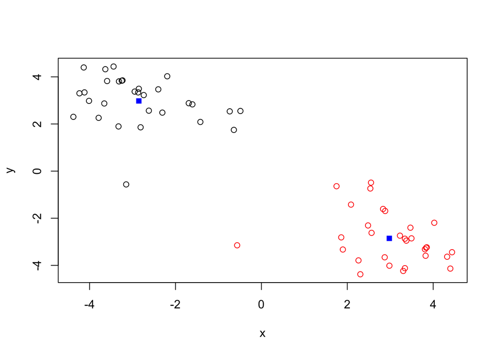

```r
plot(x, col=km$cluster)
points(km$centers, col="blue", pch=15)
```

Q. Repeat for k=3, which has the lower tot.withinss?

```r
km3 <- kmeans(x, centers = 3, nstart=20)
km3
```

```
## K-means clustering with 3 clusters of sizes 19, 11, 30
##
## Cluster means:
##           x         y
## 1  3.498484 -3.410654
## 2  2.079855 -1.890656
## 3 -2.853321  2.978320
##
## Clustering vector:
##  [1] 3 3 3 3 3 3 3 3 3 3 3 3 3 3 3 3 3 3 3 3 3 3 3 3 3 3 3 3 3 3 1 1 2 1 1
## [36] 2 1 1 1 1 1 1 2 2 2 2 1 2 1 2 1 2 2 1 1 1 1 1 1 2
##
## Within cluster sum of squares by cluster:
## [1] 14.02843 19.62170 63.76634
##  (between_SS / total_SS =  91.5 %)
##
## Available components:
##
## [1] "cluster"      "centers"      "totss"        "withinss"
## [5] "tot.withinss" "betweenss"    "size"         "iter"
## [9] "ifault"
```

```r
km3$tot.withinss
```

```
## [1] 97.41646
```

# Hierarchical clustering

Lets try on our x points

```r
# First we need to calculate point (dis)similarity
#   as the Euclidean distance between observations
dist_matrix <- dist(x)
```

Lets look at this distance matrix

```r
class(dist_matrix)
```

```
## [1] "dist"
```

```r
dim(as.matrix(dist_matrix))
```

```
## [1] 60 60
```

```r
# The hclust() function returns a hierarchical
#  clustering model
hc <- hclust(d = dist_matrix)

# the print method is not so useful here
hc
```

```
##
## Call:
## hclust(d = dist_matrix)
##
## Cluster method   : complete
## Distance         : euclidean
## Number of objects: 60
```

Lets draw the tree

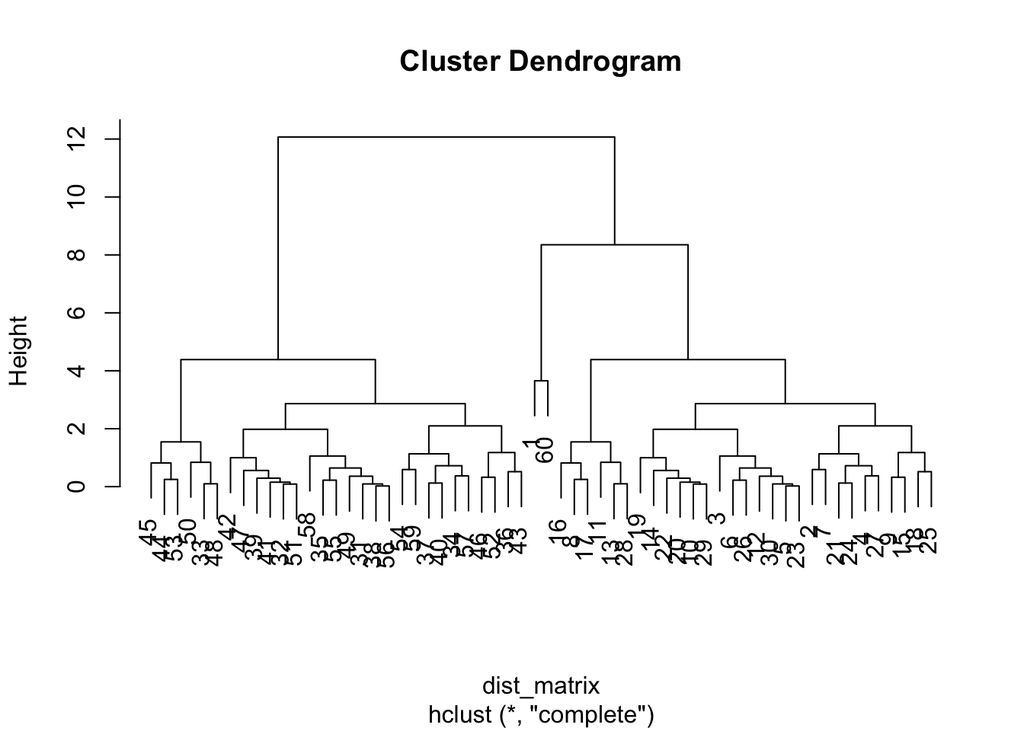

```r
plot(hc)
```

I can ‘cut’ the tree at any height to give our clusters…

```r
# Cut at height 6
cutree(hc, h=6)
```

```
##  [1] 1 2 2 2 2 2 2 2 2 2 2 2 2 2 2 2 2 2 2 2 2 2 2 2 2 2 2 2 2 2 3 3 3 3 3
## [36] 3 3 3 3 3 3 3 3 3 3 3 3 3 3 3 3 3 3 3 3 3 3 3 3 1
```

Or ask it to cut yieling `k` clusters

```r
# Give me 4 clusters please!
cutree(hc, k=4)
```

```
##  [1] 1 2 2 2 2 2 2 2 2 2 2 2 2 2 2 2 2 2 2 2 2 2 2 2 2 2 2 2 2 2 3 3 4 3 3
## [36] 3 3 3 3 3 3 3 3 4 4 3 3 4 3 4 3 3 4 3 3 3 3 3 3 1
```

## Another example

Make up some data

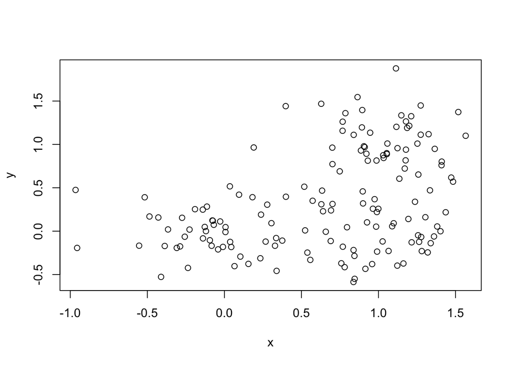

```r
# Step 1. Generate some example data for clustering
x <- rbind(
  matrix(rnorm(100, mean=0, sd = 0.3), ncol = 2),   # c1
  matrix(rnorm(100, mean = 1, sd = 0.3), ncol = 2), # c2
  matrix(c(rnorm(50, mean = 1, sd = 0.3),           # c3
           rnorm(50, mean = 0, sd = 0.3)), ncol = 2))
colnames(x) <- c("x", "y")

# Step 2. Plot the data without clustering
plot(x)
```

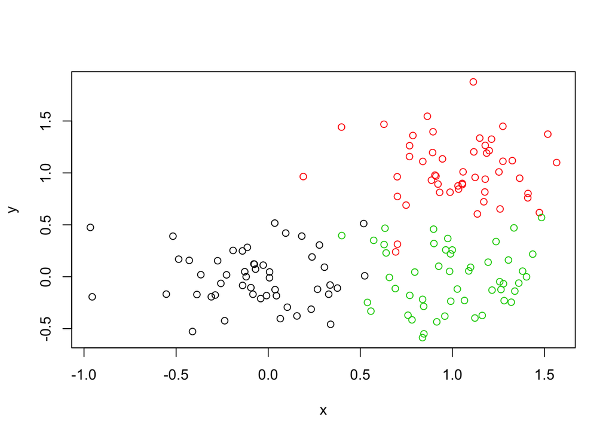

```r
# Step 3. Generate colors for known clusters
#         (just so we can compare to hclust results)
col <- as.factor( rep(c("c1","c2","c3"), each=50) )

plot(x, col=col)
```

**Q.** Use the dist(), hclust(), plot() and cutree() functions to return 2 and 3 clusters

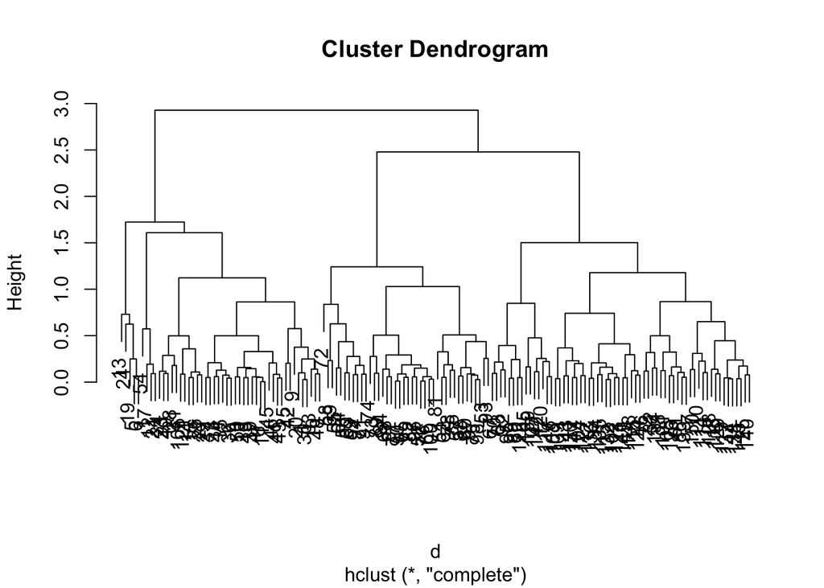

```r
# Distance matrix
d <- dist(x)
hc <- hclust(d)
plot(hc)
```

```r
# To return 2 clusters I could cut at h=2.5 or set k=2
members2 <- cutree(hc, k=2)

# To return 3 clusters I could cut at h=2 or set k=3
members3 <- cutree(hc, k=3)

# lets look at both
members <- cbind(k2=members2, k3=members3)
```

Plot

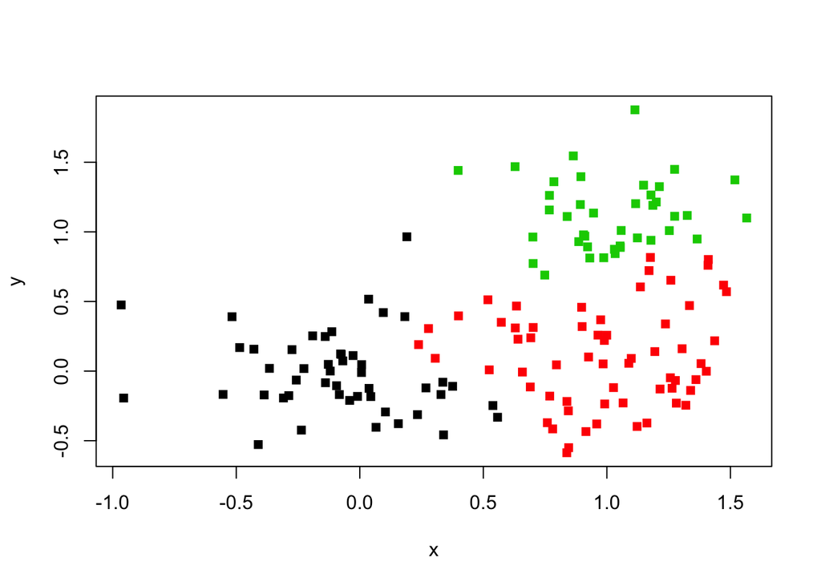

```r
plot(x, col=members3, pch=15)
```

**Q.** How does this compare to your known ‘col’ groups?

## PCA :-)

Lets make up some data

```r
## Initialize a blank 100 row by 10 column matrix
mydata <- matrix(nrow=100, ncol=10)
dim(mydata)
```

```
## [1] 100  10
```

```r
## Lets label the rows gene1, gene2 etc. to gene100
rownames(mydata) <- paste("gene", 1:100, sep="")
```

```r
## Lets label the first 5 columns wt1, wt2, wt3, wt4 and wt5
##   and the last 5 ko1, ko2 etc. to ko5 (for "knock-out")
colnames(mydata) <- c(paste("wt", 1:5, sep=""),
                    paste("ko", 1:5, sep="") )

## Fill in some fake read counts
for(i in 1:nrow(mydata)) {
  wt.values <- rpois(5, lambda=sample(x=10:1000, size=1))
  ko.values <- rpois(5, lambda=sample(x=10:1000, size=1))

  mydata[i,] <- c(wt.values, ko.values)
}

head(mydata)
```

```
##       wt1 wt2 wt3 wt4 wt5  ko1  ko2 ko3  ko4 ko5
## gene1 204 203 200 203 200  179  215 239  242 230
## gene2 801 890 854 842 875   82   86  89   87  84
## gene3 261 226 225 209 234   36   27  26   20  28
## gene4 102  88 108 109 104  337  337 311  323 332
## gene5 203 199 206 201 213 1017 1084 991 1010 995
## gene6 208 218 215 207 237  555  542 498  527 512
```

```r
#head(t(mydata))
```

```r
pca <- prcomp( t(mydata), scale=TRUE )
pca
```

[output not shown]

[output cut: 253 more lines]

[output not shown]

Lets plot our PCA plot

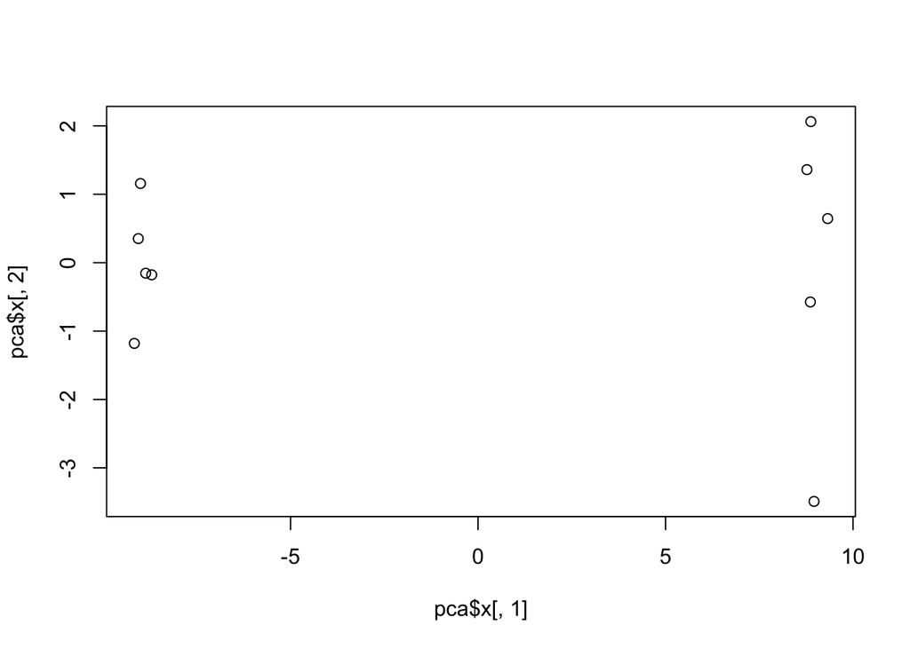

```r
## A basic PC1 vs PC2 2-D plot
plot(pca$x[,1], pca$x[,2])
```

How well are our PC’s capturing our data spread (i.e. variance)

```r
## Precent variance is often more informative to look at
pca.var <- pca$sdev^2
pca.var.per <- round(pca.var/sum(pca.var)*100, 1)

pca.var.per
```

```
##  [1] 89.2  2.4  2.2  2.0  1.4  1.2  0.6  0.5  0.4  0.0
```

Plot our scree plot

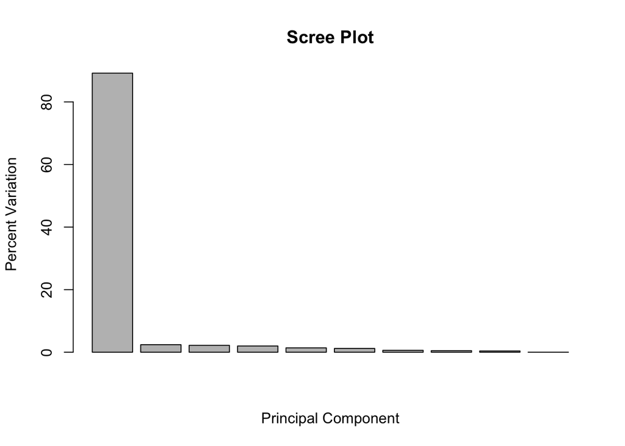

```r
barplot(pca.var.per, main="Scree Plot",
        xlab="Principal Component", ylab="Percent Variation")
```

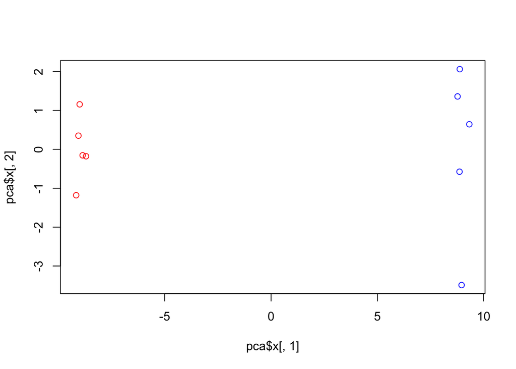

```r
# Color up our PCA plot
colvec <- colnames(mydata)
colvec[grep("wt", colvec)] <- "red"
colvec[grep("ko", colvec)] <- "blue"


plot(pca$x[,1], pca$x[,2], col=colvec)
```